# Text Mining Trump Speeches with R

Adela Sobotkova, adela@fedarch.org

24 July 2019

adapted from P J Murphy @ https://rpubs.com/pjmurphy/265713

To begin, please install the needed packages for R.

```r
Needed <- c("tm", "SnowballCC", "RColorBrewer", "ggplot2", "wordcloud", "biclust",
            "cluster", "igraph", "fpc")
install.packages(Needed, dependencies=TRUE)
```

If you get the following message:

```r
Update all/some/none? [a/s/n]:
```

enter “a” and press return

# Loading Texts

Start by saving your text files in a folder titled: “texts” This will be the “corpus” (body) of texts you are mining.

Note: The texts used in this example are a few of Donald Trump’s speeches that were copied and pasted into a text document. You can use a variety of media for this, such as PDF and HTML. The text example was chosen out of curiosity. If you would like to use these same texts, you can [download them here](https://drive.google.com/drive/folders/0B914dXn0AXvlaWhmVXdPclZrTjA).

Next, choose the type of computer you have…

*On a Mac*, save the folder to your *desktop* and use the following code chunk:

```r
cname <- file.path("~", "Desktop", "texts")
cname
```

```
## [1] "~/Desktop/texts"
```

```r
dir(cname)   # Use this to check to see that your texts have loaded.
```

```
## character(0)
```

*On a PC*, save the folder to your *C: drive* and use the following code chunk:

```r
cname <- file.path("./data", "texts")
cname
```

```
## [1] "./data/texts"
```

```r
dir(cname)
```

```
##  [1] "Trump Black History Month Speech.txt"
##  [2] "Trump CIA Speech.txt"
##  [3] "Trump Congressional Address.txt"
##  [4] "Trump CPAC Speech.txt"
##  [5] "Trump Florida Rally 2-18-17.txt"
##  [6] "Trump Immigration Speech 8-31-16.txt"
##  [7] "Trump Inauguration Speech.txt"
##  [8] "Trump National Prayer Breakfast.txt"
##  [9] "Trump Nomination Speech.txt"
## [10] "Trump Police Chiefs Speech.txt"
## [11] "Trump Response to Healthcare Bill Failure.txt"
```

# Start Analysing

Load the R package for text mining and then load your texts into R.

```r
library(tm)
docs <- VCorpus(DirSource(cname))
```

Look at one of the texts; what problems do you see ?

```r
writeLines(as.character(docs[1]))
```

```
## list(list(content = c("Well, the election, it came out really well. Next time weâ\200\231ll triple the number or quadruple it. We want to get it over 51, right? At least 51.", "", "Well this is Black History Month, so this is our little breakfast, our little get-together. Hi Lynn, how are you? Ju…
## "", "Last month, we celebrated the life of Reverend Martin Luther King, Jr., whose incredible example is unique in American history. You read all about Dr. Martin Luther King a week ago when somebody said I took the statue out of my office. It turned out that that was fake news. Fake news. The st…
## "", "I am very proud now that we have a museum on the National Mall where people can learn about Reverend King, so many other things. Frederick Douglass is an example of somebody whoâ\200\231s done an amazing job and is being recognized more and more, I noticed. Harriet Tubman, Rosa Parks, and mi…
## "", "Weâ\200\231re gonna need better schools and we need them soon. We need more jobs, we need better wages, a lot better wages. Weâ\200\231re gonna work very hard on the inner city. Ben is gonna be doing that, big league. Thatâ\200\231s one of the big things that youâ\200\231re gonna be looking …
## "", "Iâ\200\231m ready to do my part, and I will say this: Weâ\200\231re gonna work together. This is a great group, this is a group thatâ\200\231s been so special to me. You really helped me a lot. If you remember I wasnâ\200\231t going to do well with the African-American community, and after t…
## "", "So I want to thank everybody for being here."), meta = list(author = character(0), datetimestamp = list(sec = 30.8016550540924, min = 32, hour = 13, mday = 19, mon = 6, year = 119, wday = 5, yday = 199, isdst = 0), description = character(0), heading = character(0), id = "Trump Black History…
## list()
## list()
```

## Pre-process the texts

Handle problematic diacritics and special symbols

```r
for (j in seq(docs)) {
  docs[[j]] <- gsub( "â\200\231","", docs[[j]]) # remove apostrophe
  docs[[j]] <- gsub( "â\200","-", docs[[j]])  # reinsert hyphen
    docs[[j]] <- gsub("@"," ", docs[[j]])
  docs[[j]] <- gsub("\\|", " ", docs[[j]])
  docs[[j]] <- gsub("\u2028", " ", docs[[j]])
  docs[[j]] <- gsub("/"," ", docs[[j]])
}
```

Clean up text from numbers, capitals, whitespaces and unwanted words

```r
docs <- tm_map(docs, removePunctuation)
docs <- tm_map(docs, removeNumbers)
docs <- tm_map(docs, tolower)
docs <- tm_map(docs, removeWords, stopwords("english"))
docs <- tm_map(docs, removeWords, c("syllogism", "tautology"))
docs <- tm_map(docs, stripWhitespace)
docs <- tm_map(docs, PlainTextDocument)
```

*This should be the end of the preprocessing stage.* Let’s use the writeLines() function to look at the text again.

```r
writeLines(as.character(docs[1]))
```

```
## list(list(content = c("well election came really well next time well triple number quadruple want get right least ", "", "well black history month little breakfast little gettogether hi lynn just notes month honor tremendous history africanamericans throughout country throughout world really thin…
## "", "last month celebrated life reverend martin luther king jr whose incredible example unique american history read dr martin luther king week ago somebody said took statue office turned fake news fake news statue cherished one favorite things ” good ones lincoln jefferson dr martin luther king …
## "", "im proud honor heritage will honoring folks table almost cases great friends supporters darrell” met darrell defending television people side argument didnt chance right paris done amazing job hostile cnn community hes youll seven people paris ill take paris seven dont watch cnn dont get see…
## "", "im ready part will say gonna work together great group group thats special really helped lot remember wasnt going well africanamerican community heard speaking talking inner city lots things ended getting” wont go details” ended getting substantially candidates run past years now gonna take …
## ), meta = list(author = character(0), datetimestamp = list(sec = 31.1406409740448, min = 32, hour = 13, mday = 19, mon = 6, year = 119, wday = 5, yday = 199, isdst = 0), description = character(0), heading = character(0), id = character(0), language = character(0), origin = character(0))))
## list()
## list()
```

If there are additional issues, return to the data cleaning code chunks above and clean to your heart’s desire.

## Stage the Data

Now that we have a reasonably clean corpus of texts, we will now create a document term matrix. We will be using the dtm object from this point on.

```r
dtm <- DocumentTermMatrix(docs)
tdm <- TermDocumentMatrix(docs)   # this is a transposed document term matrix
```

To inspect these objects, you can use: inspect(dtm) This will, however, fill up your terminal quickly. So you may prefer to view a subset:

```r
inspect(dtm[1:5, 1:20]) # view first 5 docs & first 20 terms - modify as you like
dim(dtm) #This will display the number of documents & terms (in that order)
```

## Explore your data

Organize terms by their frequency

```r
freq <- colSums(as.matrix(dtm))
length(freq)
```

```
## [1] 3641
```

```r
ord <- order(freq)
m <- as.matrix(dtm)
dim(m)
```

```
## [1]   11 3641
```

### Save the result to a file

```r
write.csv(m, file="DocumentTermMatrix.csv")
```

### If you wish to focus on just the interesting stuff..

Start by removing sparse terms. The ‘removeSparseTerms()’ function will remove the infrequently used words, leaving only the most well-used words in the corpus.

```r
dtms <- removeSparseTerms(dtm, 0.1) # This makes a matrix that is 10% empty space, maximum.
```

## Calculate Word Frequency

There are a lot of terms, so for now, just check out some of the most and least frequently occurring words.

```r
freq <- colSums(as.matrix(dtm))
```

Check out the frequency of frequencies. The ‘colSums()’ function generates a table reporting how often each word frequency occurs. Using the ’head()" function, below, we can see the distribution of the least-frequently used words.

```r
head(table(freq), 20)
```

```
## freq
##    1    2    3    4    5    6    7    8    9   10   11   12   13   14   15
## 1634  617  322  212  125  100   78   59   59   50   38   34   27   24   24
##   16   17   18   19   20
##   15    9   14   16   12
```

The above output is two rows of numbers. The top number is the frequency with which words appear and the bottom number reflects how many words appear that frequently. Here, considering only the 20 lowest word frequencies, we can see that 1634 terms appear only once (your number may vary depending on how you cleaned your texts). There are also a lot of others that appear very infrequently.

```r
tail(table(freq), 20)
```

```
## freq
##  77  79  83  88  95 100 101 102 105 107 111 122 127 139 140 163 174 265
##   1   2   2   1   1   1   1   2   1   1   1   1   1   1   1   1   1   1
## 278 428
##   1   1
```

Considering only the 20 greatest frequencies, we can see that there is a huge disparity in how frequently some terms appear.

For a **less fine-grained look** at term freqency we can view a table of the terms we selected when we removed sparse terms, above. (Look just under the heading “If you wish to focus”.)

```r
freq <- colSums(as.matrix(dtms))
freq
```

```
##    always      back       big       can      come   country       day
##        24        75        45       100        55       174        36
##      done      even       get     going      good     great       ive
##        24        55        79       265        58       163        35
##       job      just      last       let      like      love      many
##        38        88        44        40        79        45       101
##      much     never       now       one    people president  remember
##        68        83       111       139       278        44        27
##     right      safe       say       see    states      take     thank
##       102        35        66        48        65        64       105
##    things     think      time     today  together      want       way
##        40        77        76        33        34       140        71
##      well      will     years
##        55       428        54
```

The above matrix was created using a data transformation we made earlier. What follows is an alternative that will accomplish essentially the same thing.

```r
freq <- sort(colSums(as.matrix(dtm)), decreasing=TRUE)
head(freq, 14)
```

```
##     will   people    going  country    great     want      one     know
##      428      278      265      174      163      140      139      127
##  america      now american    thank    right   theyre
##      122      111      107      105      102      102
```

**An alternate view of term frequency:**  
This will identify all terms that appear frequently (in this case, 50 or more times).

```r
findFreqTerms(dtm, lowfreq=50)   # Change "50" to whatever is most appropriate for your data.
```

```
##  [1] "also"        "america"     "american"    "back"        "believe"
##  [6] "can"         "come"        "country"     "dont"        "even"
## [11] "get"         "going"       "good"        "great"       "immigration"
## [16] "jobs"        "just"        "know"        "law"         "like"
## [21] "look"        "make"        "many"        "much"        "must"
## [26] "never"       "new"         "now"         "one"         "people"
## [31] "really"      "right"       "said"        "say"         "states"
## [36] "take"        "tell"        "thank"       "thats"       "theyre"
## [41] "think"       "time"        "united"      "want"        "way"
## [46] "well"        "will"        "work"        "world"       "years"
```

## Plot Word Frequencies

**Plot words that appear at least 50 times.**

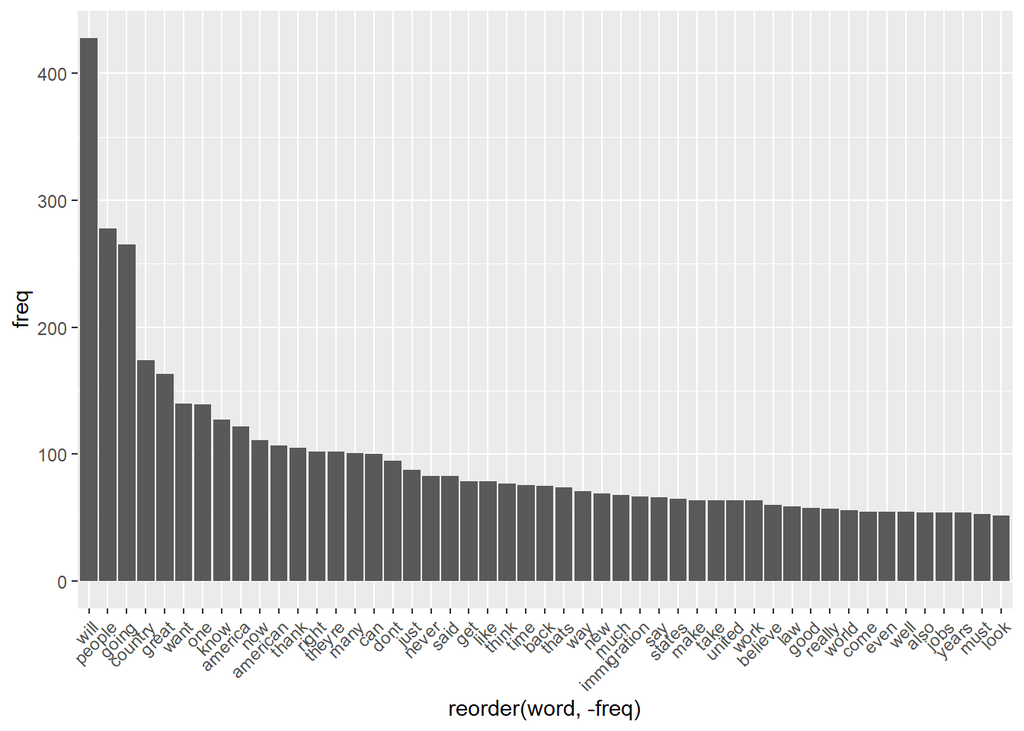

```r
library(ggplot2)
wf <- data.frame(word=names(freq), freq=freq)
p <- ggplot(subset(wf, freq>50), aes(x=reorder(word, -freq), y= freq))    +
     geom_bar(stat="identity")   +
      theme(axis.text.x=element_text(angle=45, hjust=1))
p
```

# Relationships Between Terms

## Term Correlations

If you have a term in mind that you have found to be particularly meaningful to your analysis, then you may find it helpful to identify the words that most highly correlate with that term. If words always appear together, then correlation=1.0.

```r
findAssocs(dtm, c("country" , "american"), corlimit=0.85) # specifying a correlation limit of 0.85
```

```
## $country
##   nothing    cities countries      jobs      come   biggest    donors
##      0.95      0.94      0.94      0.92      0.91      0.90      0.90
##    second     begin    border      plan    crimes     globe     meant
##      0.90      0.88      0.88      0.88      0.87      0.87      0.87
## thousands     means   workers      also   despite      take
##      0.87      0.86      0.86      0.85      0.85      0.85
##
## $american
##  restore     task     fair   budget    cycle      new promises  dollars
##     0.97     0.93     0.92     0.91     0.89     0.89     0.89     0.88
##  finally millions national     tens  foreign   middle  justice  program
##     0.88     0.88     0.88     0.88     0.87     0.87     0.86     0.86
##    break  joining   united
##     0.85     0.85     0.85
```

In this case, “country” and “american” were highly correlated with numerous other terms. Setting corlimit= to 0.85 prevented the list from being overly long. Feel free to adjust the corlimit= to any value you feel is necessary.

```r
findAssocs(dtms, "think", corlimit=0.70) # specifying a correlation limit of 0.95
```

```
## $think
## well  see good
## 0.87 0.72 0.71
```

Change “country” & “american”, or “think” to terms that actually appear in your texts.

## Word Clouds!

Humans are generally strong at visual analytics. That is part of the reason that these have become so popular. What follows are a variety of alternatives for constructing word clouds with your text.

First load the package that makes word clouds in R.

```r
library(wordcloud)
```

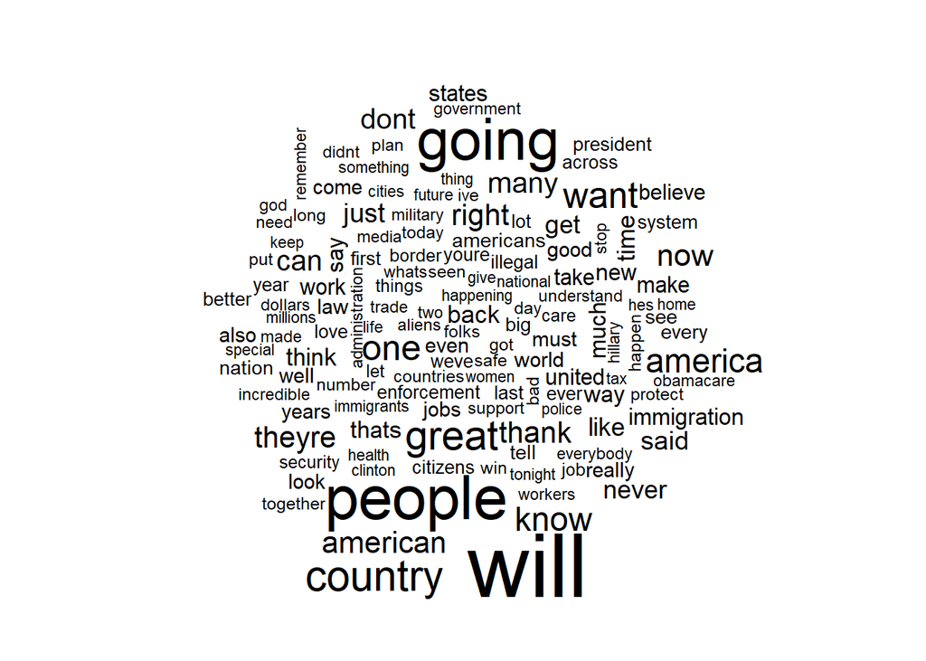

```r
set.seed(142)
wordcloud(names(freq), freq, min.freq=25)
```

Note: The “set.seed() function just makes the configuration of the layout of the clouds consistent each time you plot them. You can omit that part if you are not concerned with preserving a particular layout.

Then play with wordclouds - change the word occurrence minimum, add, color, rotate terms, etc. :)

Plot the 100 most frequently occurring words with some color.

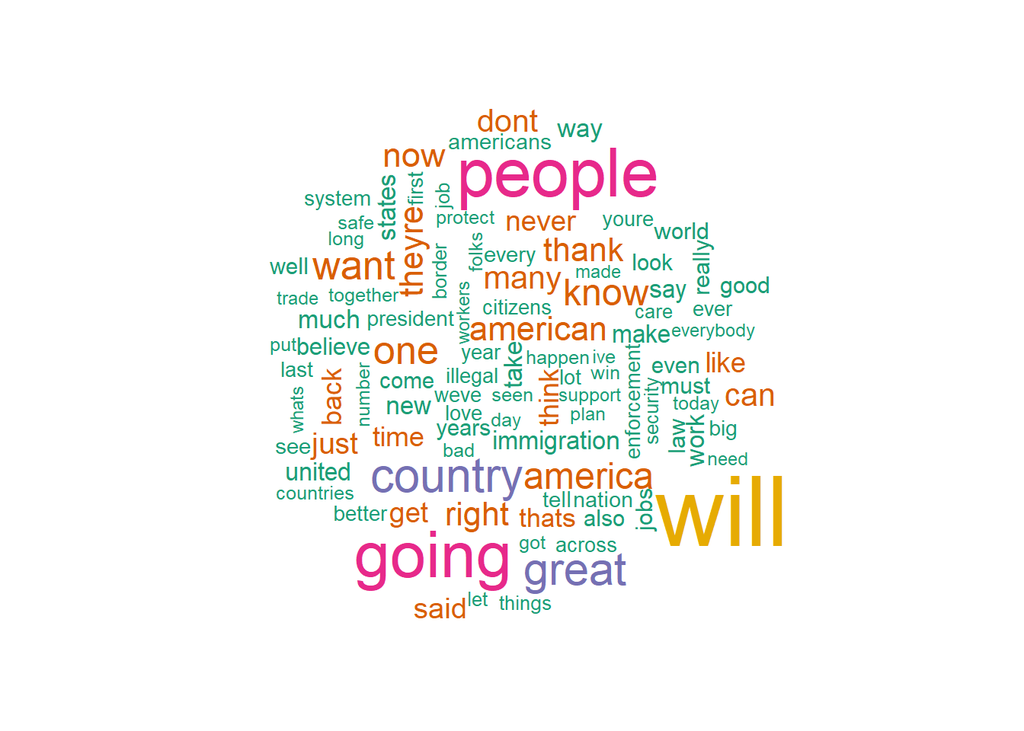

```r
dark2 <- brewer.pal(6, "Dark2")
wordcloud(names(freq), freq, max.words=100, rot.per=0.2, colors=dark2)
```